# metropolis

Alexander Keil

2019-12-06

## A guided walk through the Metropolis algorithmm

The following vignette contains code to accompany the paper “Markov unchained: a guided walk through the Metropolis algorithm.” The code walks the reader through

- Reading in the data
- Finding maximum likelihood estimates of the log odds ratio and risk difference
- Simulating posterior distributions of the log odds ratio and risk difference using the following algorithms (described in the paper)
  - Random walk metropolis
  - Guided metropolis
  - Guided, adaptive metropolis
  - Guided, adaptive metropolis with normal priors
- Using the “metropolis” r package to carry out the same analysis to simulate a posterior distribution for a logistic model under uniform or normal priors
- *Note* each algorithm used here only runs for 10,000 iterations (to save computational time when installing package). The results will vary more than they would with the larger number of iterations used in the paper.

## The data

A case control study of leukemia (y=1) and residence around strong magnetic fields (x=1)

```r
y = c(rep(1, 36), rep(0, 198)) # leukemia cases
x = c(rep(1, 3), rep(0, 33), rep(1, 5), rep(0, 193)) # exposure
```

## Helper functions

These functions will be used throughout

```r
#helper functions
expit <- function(mu) 1/(1+exp(-mu))

loglik = function(y,x,beta){
  # calculate the log likelihood
  lli = dbinom(y, 1, expit(beta[1] + x*beta[2]), log=TRUE)
  sum(lli)
}

riskdifference = function(y,x,beta){
  # baseline odds (offset)
  # calculate a risk difference
  poprisk = 4.8/100000
  popodds = poprisk/(1-poprisk)
  studyodds = mean(y)/(1-mean(y))
  r1 = expit(log(popodds/studyodds) + beta[1] + beta[2])
  r0 = expit(log(popodds/studyodds) + beta[1])
  mean(r1-r0)
}
```

## Maximum likelihood estimates

```r
data = data.frame(leuk=y, magfield=x)
mod = glm(leuk ~ magfield, family=binomial(), data=data)
summary(mod)$coefficients

beta1 = summary(mod)$coefficients[2,1]
se1 = summary(mod)$coefficients[2,2]
cat("\n\nMaximum likelihood beta coefficient (95% CI)\n")
round(c(beta=beta1, ll=beta1+se1*qnorm(0.025), ul=beta1+se1*qnorm(0.975)), 2)

cat("\n\nMaximum likelihood odds ratio (95% CI)\n")
round(exp(c(beta=beta1, ll=beta1+se1*qnorm(0.025), ul=beta1+se1*qnorm(0.975))), 2)

cat("\n\nMaximum likelihood risk difference (multiplied by 1000) \n")
round(c(rd_1000=riskdifference(y,x,mod$coefficients)*1000), 2)
```

```
##              Estimate Std. Error   z value     Pr(>|z|)
## (Intercept) -1.766183   0.188373 -9.375988 6.853094e-21
## magfield     1.255357   0.754200  1.664488 9.601492e-02
##
##
## Maximum likelihood beta coefficient (95% CI)
##  beta    ll    ul
##  1.26 -0.22  2.73
##
##
## Maximum likelihood odds ratio (95% CI)
##  beta    ll    ul
##  3.51  0.80 15.39
##
##
## Maximum likelihood risk difference (multiplied by 1000)
## rd_1000
##    0.11
```

## Random walk metropolis

```r
# initialize
M=10000
set.seed(91828)
beta_post = matrix(nrow=M, ncol=2)
colnames(beta_post) = c('beta0', 'beta1')
accept = numeric(M)
rd = numeric(M)
beta_post[1,] = c(2,-3)
rd[1] = riskdifference(y,x,beta_post[1,])
accept[1] = 1
for(i in 2:M){
  oldb = beta_post[i-1,]
  prop = rnorm(2, sd=0.2)
  newb = oldb+prop
  num = loglik(y,x,newb)
  den = loglik(y,x,oldb)
  acceptprob = exp(num-den)
  acc = (acceptprob > runif(1))
  if(acc){
    beta_post[i,] = newb
    accept[i] = 1
  }else{
    beta_post[i,] = oldb
    accept[i] = 0
  }
  rd[i] = 1000*riskdifference(y,x,beta_post[i,])
}
```

## Inspecting output

```r
mean(accept)
```

```
## [1] 0.6551
```

```r
summary(beta_post)
```

```
##      beta0            beta1
##  Min.   :-2.518   Min.   :-3.9483
##  1st Qu.:-1.902   1st Qu.: 0.7389
##  Median :-1.776   Median : 1.2292
##  Mean   :-1.770   Mean   : 1.1714
##  3rd Qu.:-1.651   3rd Qu.: 1.7004
##  Max.   : 2.000   Max.   : 3.9189
```

```r
init = beta_post[1,]
postmean = apply(beta_post[-c(1:1000),], 2, mean)
cat("Posterior mean\n")
```

```
## Posterior mean
```

```r
round(postmean, 2)
```

```
## beta0 beta1
## -1.78  1.22
```

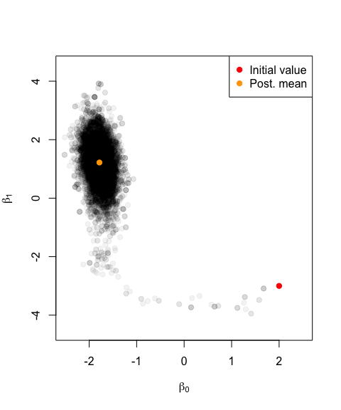

```r
plot(beta_post, pch=19, col=rgb(0,0,0,0.05), xlab=expression(beta[0]), ylab=expression(beta[1]), xlim=c(-2.5,2.5), ylim=c(-4.5,4.5))
points(init[1], init[2], col="red", pch=19)
points(postmean[1], postmean[2], col="orange", pch=19)
legend("topright", col=c("red", "orange"), legend=c("Initial value", "Post. mean"), pch=19)
```

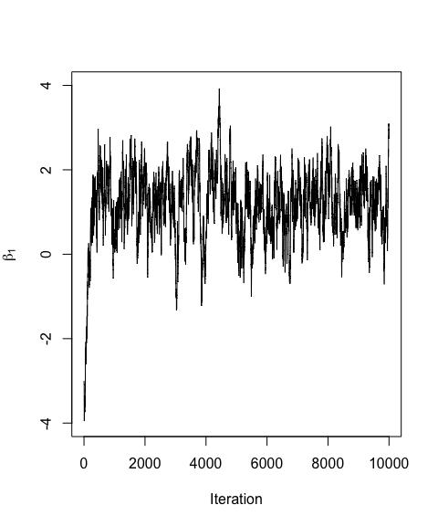

```r
plot(beta_post[,2], type='l',  ylab=expression(beta[1]), xlab="Iteration", ylim=c(-4, 4))
```

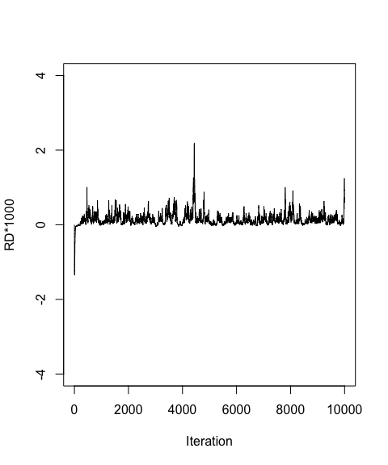

```r
plot(rd, type='l',  ylab="RD*1000", xlab="Iteration", ylim=c(-4, 4))
```

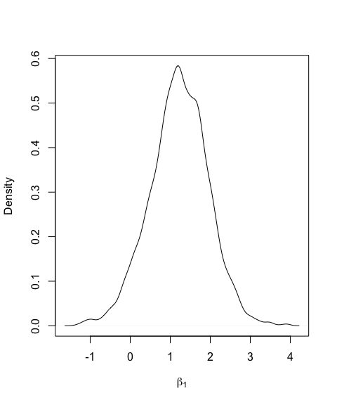

```r
plot(density(beta_post[-c(1:1000),2]), xlab=expression(beta[1]), ylab="Density", main="")
```

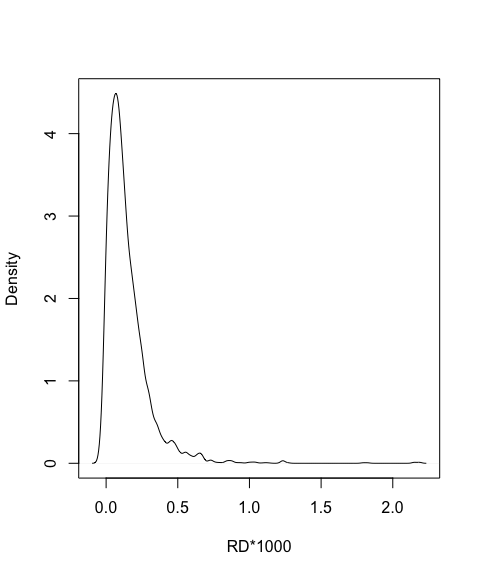

```r
plot(density(rd[-c(1:1000)]), xlab="RD*1000", ylab="Density", main="")
```

## Guided metropolis

```r
# initialize
M=10000
set.seed(91828)
beta_post_guide = matrix(nrow=M, ncol=2)
colnames(beta_post_guide) = c('beta0', 'beta1')
accept = numeric(M)
rd_guide = numeric(M)
beta_post_guide[1,] = c(2,-3)
rd_guide[1] = riskdifference(y,x,beta_post_guide[1,])
accept[1] = 1
dir = 1
for(i in 2:M){
  oldb = beta_post_guide[i-1,]
  prop = dir*abs(rnorm(2, sd=0.2))
  newb = oldb+prop
  num = loglik(y,x,newb)
  den = loglik(y,x,oldb)
  acceptprob = exp(num-den)
  acc = (acceptprob > runif(1))
  if(acc){
    beta_post_guide[i,] = newb
    accept[i] = 1
  }else{
    beta_post_guide[i,] = oldb
    accept[i] = 0
    dir = dir*-1
  }
  rd_guide[i] = 1000*riskdifference(y,x,beta_post_guide[i,])
}

postmean = apply(beta_post_guide[-c(1:1000),], 2, mean)
cat("Posterior mean, guided\n")
```

```
## Posterior mean, guided
```

```r
round(postmean, 2)
```

```
## beta0 beta1
## -1.80  1.41
```

## Contrasting output with random walk

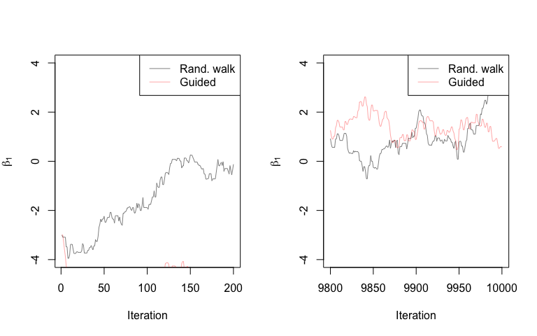

```r
col1 = rgb(0,0,0,.5)
col2 = rgb(1,0,0,.35)
par(mfcol=c(1,2))

#trace plots
plot(beta_post[1:200,2], type='l',  ylab=expression(beta[1]), xlab="Iteration", ylim=c(-4, 4), col=col1)
lines(beta_post_guide[1:200,2], col=col2)
legend("topright", lty=1, col=c(col1, col2), legend=c("Rand. walk", "Guided"))
plot(9800:10000, beta_post[9800:10000,2], type='l',  ylab=expression(beta[1]), xlab="Iteration", ylim=c(-4, 4), col=col1)
lines(9800:10000, beta_post_guide[9800:10000,2], col=col2)
legend("topright", lty=1, col=c(col1, col2), legend=c("Rand. walk", "Guided"))
```

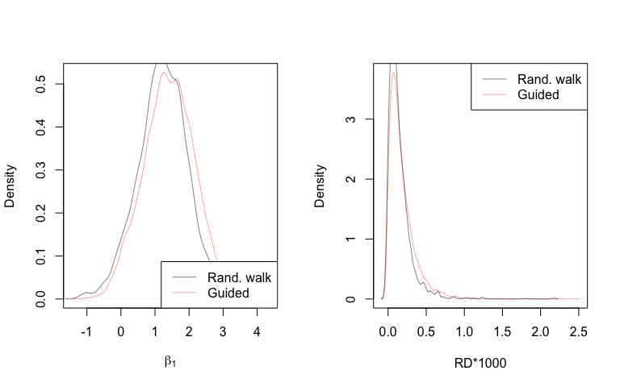

```r
# density plots
plot(density(beta_post_guide[-c(1:1000),2]), col=col2, xlab=expression(beta[1]), ylab="Density", main="")
lines(density(beta_post[-c(1:1000),2]), col=col1)
legend("bottomright", lty=1, col=c(col1, col2), legend=c("Rand. walk", "Guided"))


plot(density(rd_guide[-c(1:1000)]), xlab="RD*1000", ylab="Density", main="", col=col2)
lines(density(rd[-c(1:1000)]), col=col1)
legend("topright", lty=1, col=c(col1, col2), legend=c("Rand. walk", "Guided"))
```

```r
par(mfcol=c(1,1))
```

## Guided, adaptive metropolis algorithm

```r
# initialize
M=10000
burnin=1000
set.seed(91828)
beta_post_adaptguide = matrix(nrow=M+burnin, ncol=2)
colnames(beta_post_adaptguide) = c('beta0', 'beta1')
accept = numeric(M+burnin)
rd_adaptguide = numeric(M+burnin)
beta_post_adaptguide[1,] = c(2,-3)
rd_adaptguide[1] = riskdifference(y,x,beta_post[1,])
accept[1] = 1
prop.sigma = c(0.2, 0.2)
dir = 1
for(i in 2:(M+burnin)){
  if((i < burnin) & (i > 25)){
    prop.sigma = apply(beta_post_adaptguide[max(1, i-100):(i-1),], 2, sd)
  }
  oldb = beta_post_adaptguide[i-1,]
  prop = dir*abs(rnorm(2, sd=prop.sigma))
  newb = oldb+prop
  num = loglik(y,x,newb)
  den = loglik(y,x,oldb)
  acceptprob = exp(num-den)
  acc = (acceptprob > runif(1))
  if(acc){
    beta_post_adaptguide[i,] = newb
    accept[i] = 1
  }else{
    beta_post_adaptguide[i,] = oldb
    accept[i] = 0
    dir = dir*-1
  }
  rd_adaptguide[i] = 1000*riskdifference(y,x,beta_post_adaptguide[i,])
}
postmean = apply(beta_post_adaptguide[-c(1:1000),], 2, mean)
cat("Posterior mean, guided and adaptive\n")
```

```
## Posterior mean, guided and adaptive
```

```r
round(postmean, 2)
```

```
## beta0 beta1
## -1.78  1.22
```

## Contrasting output

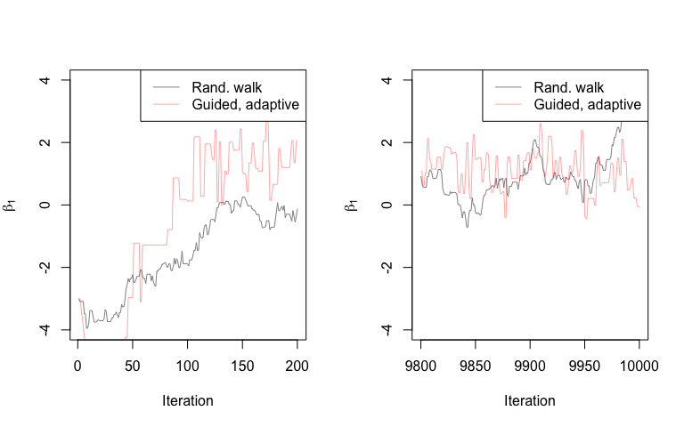

```r
col1 = rgb(0,0,0,.5)
col2 = rgb(1,0,0,.35)
par(mfcol=c(1,2))

#trace plots
plot(beta_post[1:200,2], type='l',  ylab=expression(beta[1]), xlab="Iteration", ylim=c(-4, 4), col=col1)
lines(beta_post_adaptguide[1:200,2], col=col2)
legend("topright", lty=1, col=c(col1, col2), legend=c("Rand. walk", "Guided, adaptive"))
plot(9800:10000, beta_post[9800:10000,2], type='l',  ylab=expression(beta[1]), xlab="Iteration", ylim=c(-4, 4), col=col1)
lines(9800:10000, beta_post_adaptguide[9800:10000,2], col=col2)
legend("topright", lty=1, col=c(col1, col2), legend=c("Rand. walk", "Guided, adaptive"))
```

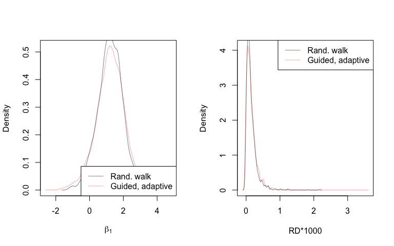

```r
# density plots
plot(density(beta_post_adaptguide[-c(1:1000),2]), col=col2, xlab=expression(beta[1]), ylab="Density", main="")
lines(density(beta_post[-c(1:1000),2]), col=col1)
legend("bottomright", lty=1, col=c(col1, col2), legend=c("Rand. walk", "Guided, adaptive"))


plot(density(rd_adaptguide[-c(1:1000)]), xlab="RD*1000", ylab="Density", main="", col=col2)
lines(density(rd[-c(1:1000)]), col=col1)
legend("topright", lty=1, col=c(col1, col2), legend=c("Rand. walk", "Guided, adaptive"))
```

```r
par(mfcol=c(1,1))
```

## Guided, adaptive metropolis algorithm using normal priors

```r
# initialize
M=10000
burnin=1000
set.seed(91828)
beta_post_adaptguide2 = matrix(nrow=M+burnin, ncol=2)
colnames(beta_post_adaptguide2) = c('beta0', 'beta1')
accept = numeric(M+burnin)
rd_adaptguide2 = numeric(M+burnin)
beta_post_adaptguide2[1,] = c(2,-3)
rd_adaptguide2[1] = riskdifference(y,x,beta_post[1,])
accept[1] = 1
prop.sigma = c(0.2, 0.2)
dir = 1
for(i in 2:(M+burnin)){
  if((i < burnin) & (i > 25)){
    prop.sigma = apply(beta_post_adaptguide2[max(1, i-100):(i-1),], 2, sd)
  }
  oldb = beta_post_adaptguide2[i-1,]
  prop = dir*abs(rnorm(2, sd=prop.sigma))
  newb = oldb+prop
  num = loglik(y,x,newb) + dnorm(newb[1], mean=0, sd=sqrt(100), log=TRUE) + dnorm(newb[2], mean=0, sd=sqrt(0.5), log=TRUE)
  den = loglik(y,x,oldb) + dnorm(oldb[1], mean=0, sd=sqrt(100), log=TRUE) + dnorm(oldb[2], mean=0, sd=sqrt(0.5), log=TRUE)
  acceptprob = exp(num-den)
  acc = (acceptprob > runif(1))
  if(acc){
    beta_post_adaptguide2[i,] = newb
    accept[i] = 1
  }else{
    beta_post_adaptguide2[i,] = oldb
    accept[i] = 0
    dir = dir*-1
  }
  rd_adaptguide2[i] = 1000*riskdifference(y,x,beta_post_adaptguide2[i,])
}
postmean = apply(beta_post_adaptguide2[-c(1:1000),], 2, mean)
cat("Posterior mean, guided and adaptive\n")
```

```
## Posterior mean, guided and adaptive
```

```r
round(postmean, 2)
```

```
## beta0 beta1
## -1.75  0.54
```

## Inspecting output

```r
mean(accept)
```

```
## [1] 0.5552727
```

```r
init = beta_post_adaptguide[1,]
postmean = apply(beta_post_adaptguide[-c(1:1000),], 2, mean)
cat("Posterior mean, uniform priors\n")
```

```
## Posterior mean, uniform priors
```

```r
round(postmean, 2)
```

```
## beta0 beta1
## -1.78  1.22
```

```r
init2 = beta_post_adaptguide2[1,]
postmean2 = apply(beta_post_adaptguide2[-c(1:1000),], 2, mean)
cat("Posterior mean, informative normal priors\n")
```

```
## Posterior mean, informative normal priors
```

```r
round(postmean2, 2)
```

```
## beta0 beta1
## -1.75  0.54
```

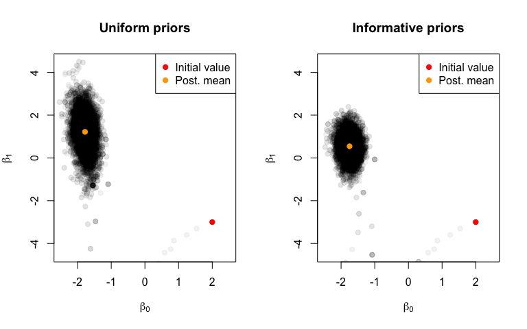

```r
par(mfcol=c(1,2))
plot(beta_post_adaptguide, pch=19, col=rgb(0,0,0,0.05), xlab=expression(beta[0]), ylab=expression(beta[1]), xlim=c(-2.5,2.5), ylim=c(-4.5,4.5), main="Uniform priors")
points(init[1], init[2], col="red", pch=19)
points(postmean[1], postmean[2], col="orange", pch=19)
legend("topright", col=c("red", "orange"), legend=c("Initial value", "Post. mean"), pch=19)

plot(beta_post_adaptguide2, pch=19, col=rgb(0,0,0,0.05), xlab=expression(beta[0]), ylab=expression(beta[1]), xlim=c(-2.5,2.5), ylim=c(-4.5,4.5), main="Informative priors")
points(init2[1], init2[2], col="red", pch=19)
points(postmean2[1], postmean2[2], col="orange", pch=19)
legend("topright", col=c("red", "orange"), legend=c("Initial value", "Post. mean"), pch=19)
```

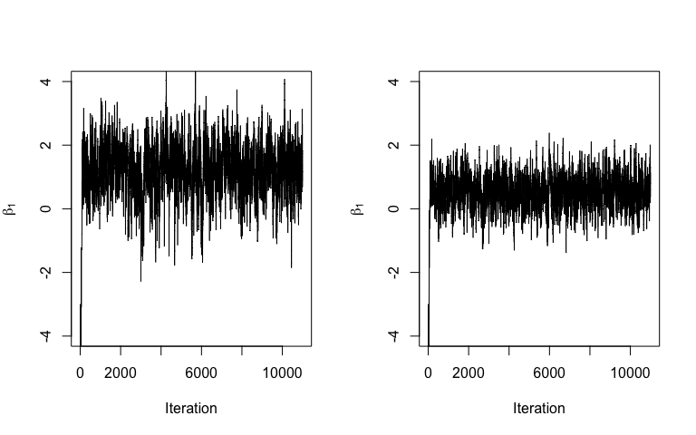

```r
par(mfcol=c(1,2))
plot(beta_post_adaptguide[,2], type='l',  ylab=expression(beta[1]), xlab="Iteration", ylim=c(-4, 4))
plot(beta_post_adaptguide2[,2], type='l',  ylab=expression(beta[1]), xlab="Iteration", ylim=c(-4, 4))
```

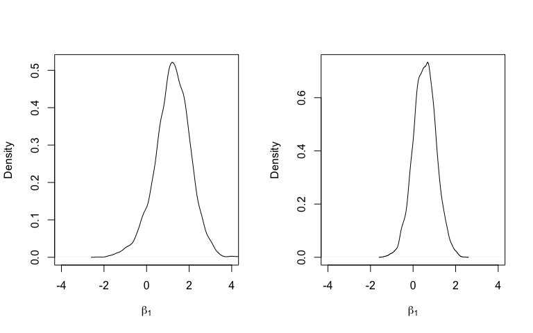

```r
plot(density(beta_post_adaptguide[-c(1:1000),2]), xlab=expression(beta[1]), ylab="Density", main="", xlim=c(-4, 4))
plot(density(beta_post_adaptguide2[-c(1:1000), 2]), xlab=expression(beta[1]), ylab="Density", main="", xlim=c(-4, 4))
```

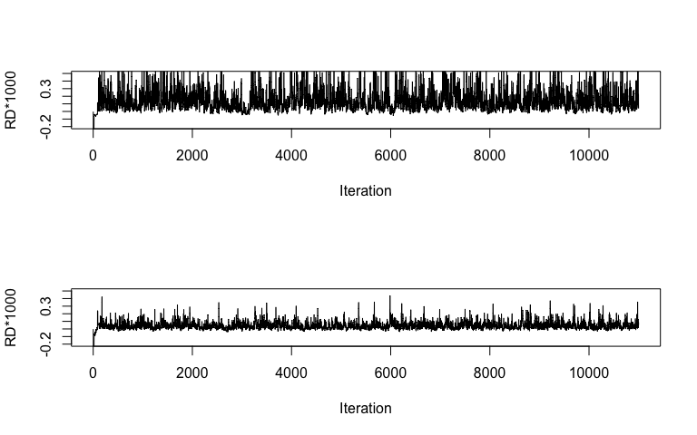

```r
par(mfcol=c(2,1))

plot(rd_adaptguide, type='l',  ylab="RD*1000", xlab="Iteration", ylim=c(-.2, .5))
plot(rd_adaptguide2, type='l',  ylab="RD*1000", xlab="Iteration", ylim=c(-.2, .5))
```

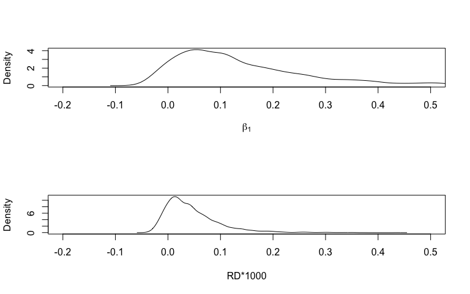

```r
plot(density(rd_adaptguide[-c(1:1000)]), xlab=expression(beta[1]), ylab="Density", main="", xlim=c(-.2, .5))
plot(density(rd_adaptguide2[-c(1:1000)]), xlab="RD*1000", ylab="Density", main="", xlim=c(-.2, .5))
```

```r
par(mfcol=c(1,1))
```

## Using the R package

Given what you know, running the R package function `metropolis_glm` should be fairly straightforward. The following example calls in the case-control data used above and compares a randome Walk metropolis algorithmn (with N(0, 0.05), N(0, 0.1) proposal distribution) with a guided, adaptive algorithm.

```r
library(metropolis)
data("magfields", package="metropolis")

# random walk
res.rw = metropolis_glm(y ~ x, data=magfields, family=binomial(), iter=20000, burnin=3000, adapt=FALSE, guided=FALSE, block=TRUE, inits=c(2,-3), control = metropolis.control(prop.sigma.start = c(0.05, .1)))

summary(res.rw, keepburn = FALSE)
```

```
## $nsamples
## [1] 20000
##
## $sd
## (Intercept)           x
##   0.1870940   0.8565178
##
## $se
## (Intercept)           x
##   0.0109079   0.1120727
##
## $ESS_beta
## [1] 294.19637  58.40808
##
## $postmean
##                  mean normal_lci normal_uci
## (Intercept) -1.778688 -2.1453924  -1.411984
## x            1.240300 -0.4384751   2.919075
##
## $postmedian
##                median   pctl_lci  pctl_uci
## (Intercept) -1.774736 -2.1594707 -1.413966
## x            1.260167 -0.5570205  2.934671
##
## $postmode
##                  mode   hpd_lci   hpd_uci
## (Intercept) -1.772201 -2.582496 -1.478352
## x            1.103599 -1.363172  2.649742
```

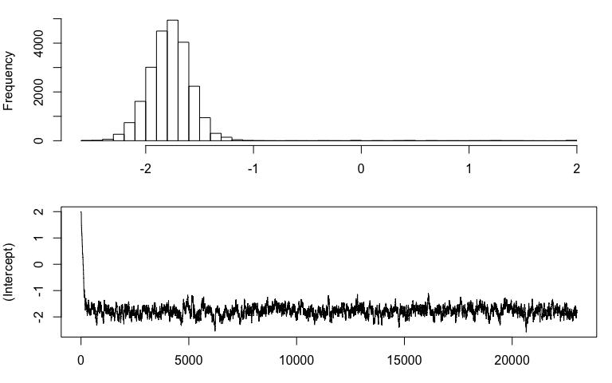

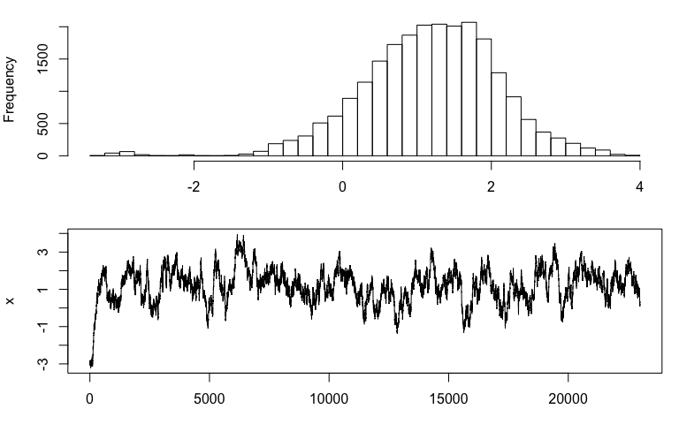

```r
plot(res.rw, par = 1:2, keepburn=TRUE)
```

```r
# guided, adaptive
res.ga = metropolis_glm(y ~ x, data=magfields, family=binomial(), iter=20000, burnin=3000, adapt=TRUE, guided=TRUE, block=FALSE, inits=c(2,-3))

summary(res.ga, keepburn = FALSE)
```

```
## $nsamples
## [1] 20000
##
## $sd
## (Intercept)           x
##   0.1887433   0.8039617
##
## $se
## (Intercept)           x
## 0.002139775 0.009397736
##
## $ESS_beta
## [1] 7780.489 7318.537
##
## $postmean
##                  mean normal_lci normal_uci
## (Intercept) -1.783400 -2.1533369  -1.413463
## x            1.195689 -0.3800755   2.771454
##
## $postmedian
##                median   pctl_lci  pctl_uci
## (Intercept) -1.779390 -2.1692698 -1.429546
## x            1.204767 -0.4308701  2.719736
##
## $postmode
##                   mode   hpd_lci   hpd_uci
## (Intercept) -1.7779101 -2.522788 -1.480541
## x            0.9658311 -2.614918  2.468663
```

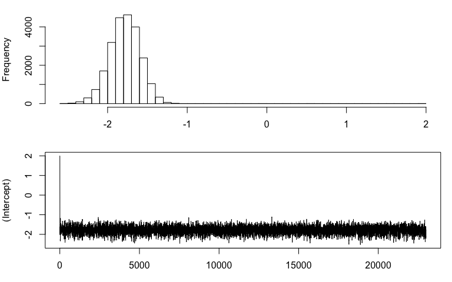

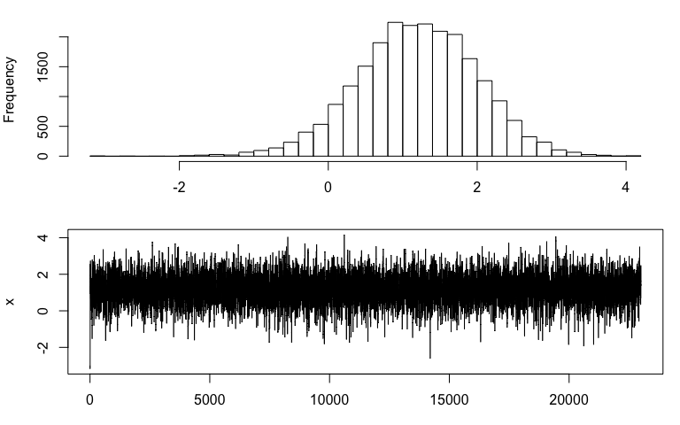

```r
plot(res.ga, par = 1:2, keepburn=TRUE)
```

## Using the R package, smart initial values

Finally, we can use the “glm” option in initial values to initialize the chain with the MLE estimates. This can eke out slightly more efficiency and allow reduced burnin.

```r
# guided, adaptive
res.ga.init = metropolis_glm(y ~ x, data=magfields, family=binomial(), iter=20000, burnin=1000, adapt=TRUE, guided=TRUE, block=FALSE, inits="glm")

summary(res.ga.init, keepburn = FALSE)
```

```
## $nsamples
## [1] 20000
##
## $sd
## (Intercept)           x
##   0.1910264   0.8117856
##
## $se
## (Intercept)           x
## 0.002187349 0.009279116
##
## $ESS_beta
## [1] 7626.942 7653.666
##
## $postmean
##                  mean normal_lci normal_uci
## (Intercept) -1.779687 -2.1540987  -1.405275
## x            1.190642 -0.4004577   2.781742
##
## $postmedian
##                median   pctl_lci  pctl_uci
## (Intercept) -1.774436 -2.1665633 -1.418378
## x            1.230554 -0.5138752  2.703918
##
## $postmode
##                  mode   hpd_lci   hpd_uci
## (Intercept) -1.746801 -2.590891 -1.472937
## x            1.386760 -3.350825  2.484321
```

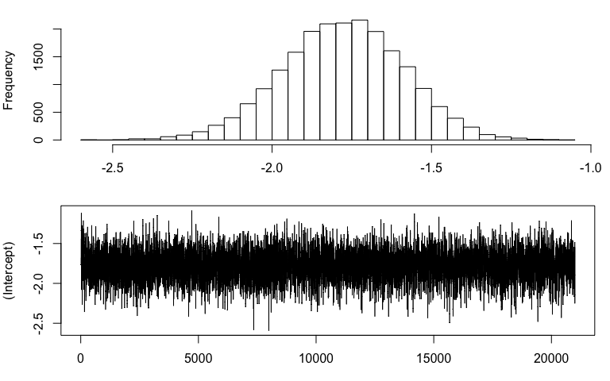

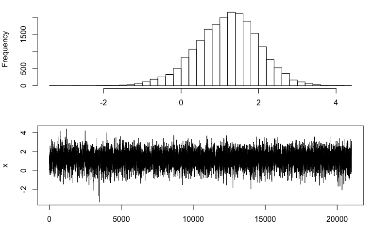

```r
plot(res.ga.init, par = 1:2, keepburn=TRUE)
```

## Extending the logistic model results after samples are generated

Using the function, “risk difference” from above, we can use the output from our prior model to get Bayesian estimates of the risk diffence. In general, this is a useful way to extend MCMC simulations to new estimands that may not be directly parameterized in the model.

```r
# guided, adaptive
beta = as.matrix(res.ga.init$parms[, c("b_0", "b_1")])

y = magfields$y
X = cbind(rep(1, dim(magfields)[1]), magfields$x)

1000*riskdifference(y,X,beta[1,])
```

```
## [1] 0.1132425
```

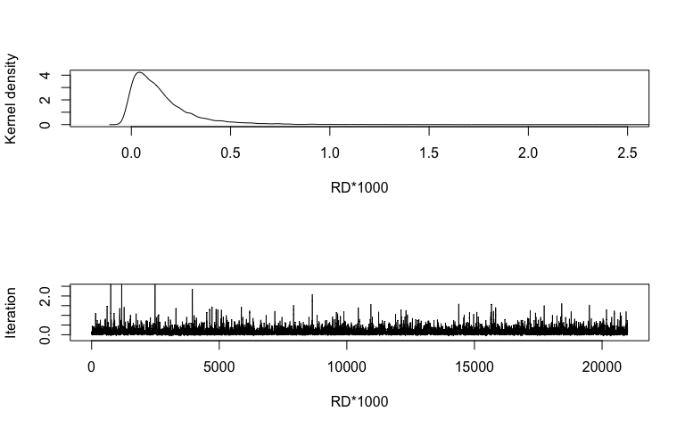

```r
# calculate risk difference for every value of model coefficients
rd.ga.init = apply(beta, 1, function(b) 1000*riskdifference(y,X,b))

par(mfcol=c(2,1))
 plot(density(rd.ga.init), xlab = "RD*1000", ylab="Kernel density", main="", xlim=c(-.2, 2.5))
 plot(rd.ga.init, type='l', xlab = "RD*1000", ylab="Iteration", ylim=c(-.2, 2.5))
```

```r
par(mfcol=c(1,1))

# posterior mean, median, credible intervals
mean(rd.ga.init[-c(1:1000)])
```

```
## [1] 0.1517853
```

```r
quantile(rd.ga.init[-c(1:1000)], p = c(.5, .025, .975) )
```

```
##         50%        2.5%       97.5%
##  0.10763217 -0.01949789  0.59457738
```